# Week 4 Assignment-Practical Machine Learning

Anuvab Palit

24 August 2018

** Introduction **

Using devices such as Jawbone Up, Nike FuelBand, and Fitbit it is now possible to collect a large amount of data about personal activity relatively inexpensively. These type of devices are part of the quantified self movement – a group of enthusiasts who take measurements about themselves regularly to improve their health, to find patterns in their behavior, or because they are tech geeks. One thing that people regularly do is quantify how much of a particular activity they do, but they rarely quantify how well they do it. In this project, your goal will be to use data from accelerometers on the belt, forearm, arm, and dumbell of 6 participants. They were asked to perform barbell lifts correctly and incorrectly in 5 different ways. More information is available from the website here: [http://web.archive.org/web/20161224072740/http:/groupware.les.inf.puc-rio.br/har] (see the section on the Weight Lifting Exercise Dataset).

# ** Data Source **

The training data for this project are available here:

[https://d396qusza40orc.cloudfront.net/predmachlearn/pml-training.csv]

The test data are available here:

[https://d396qusza40orc.cloudfront.net/predmachlearn/pml-testing.csv]

The data for this project come from this source: [http://groupware.les.inf.puc-rio.br/har]. If you use the document you create for this class for any purpose please cite them as they have been very generous in allowing their data to be used for this kind of assignment.

## ** 1. Loading the Dataset**

The Dataset has been downloaded from the internet and has been loaded into two seperate dataframes, __“training__ and **“testing”**. The __“training__ data set has 19622 number of records and the __“testing__ data set has 20 records. The number of variables is 160.

```r
library(caret)
```

```r
library(rpart)
library(rpart.plot)
library(RColorBrewer)
library(RGtk2)
library(rattle)
library(randomForest)
library(gbm)
```

Here are the datasets, loaded directly from web and then downloaded.

```r
train_url <- "http://d396qusza40orc.cloudfront.net/predmachlearn/pml-training.csv"
test_url  <- "http://d396qusza40orc.cloudfront.net/predmachlearn/pml-testing.csv"


init_org_training_data <- read.csv(url(train_url))
init_org_testing_data <- read.csv(url(test_url))

dim(init_org_training_data)
```

```
## [1] 19622   160
```

```r
dim(init_org_testing_data)
```

```
## [1]  20 160
```

# ** 2. Data Cleansing **

There are 3 parts in Data Cleansing.

### **A.** Removing Variables which are having nearly zero variance.

```r
non_zero_var <- nearZeroVar(init_org_training_data)


org_training_data <- init_org_training_data[,-non_zero_var]
org_testing_data <- init_org_testing_data[,-non_zero_var]

dim(org_training_data)
```

```
## [1] 19622   100
```

```r
dim(org_testing_data)
```

```
## [1]  20 100
```

### **B.** Removing Variables which are having NA values. Our threshhold is 95%.

```r
na_val_col <- sapply(org_training_data, function(x) mean(is.na(x))) > 0.95

org_training_data <- org_training_data[,na_val_col == FALSE]
org_testing_data <- org_testing_data[,na_val_col == FALSE]

dim(org_training_data)
```

```
## [1] 19622    59
```

```r
dim(org_testing_data)
```

```
## [1] 20 59
```

```r
org_training_data <- org_training_data[,8:59]
org_testing_data <- org_testing_data[,8:59]

dim(org_training_data)
```

```
## [1] 19622    52
```

```r
dim(org_testing_data)
```

```
## [1] 20 52
```

We can also check if the training data has the **“classe”** variable in it and the testing data has **“problem_id”** variable in it.

```r
##colnames_train <- names(org_training_data)

##org_training_data <- init_org_training_data[, c(colnames_train, "problem_id")]

colnames(org_training_data)
```

```
##  [1] "pitch_belt"           "yaw_belt"             "total_accel_belt"
##  [4] "gyros_belt_x"         "gyros_belt_y"         "gyros_belt_z"
##  [7] "accel_belt_x"         "accel_belt_y"         "accel_belt_z"
## [10] "magnet_belt_x"        "magnet_belt_y"        "magnet_belt_z"
## [13] "roll_arm"             "pitch_arm"            "yaw_arm"
## [16] "total_accel_arm"      "gyros_arm_x"          "gyros_arm_y"
## [19] "gyros_arm_z"          "accel_arm_x"          "accel_arm_y"
## [22] "accel_arm_z"          "magnet_arm_x"         "magnet_arm_y"
## [25] "magnet_arm_z"         "roll_dumbbell"        "pitch_dumbbell"
## [28] "yaw_dumbbell"         "total_accel_dumbbell" "gyros_dumbbell_x"
## [31] "gyros_dumbbell_y"     "gyros_dumbbell_z"     "accel_dumbbell_x"
## [34] "accel_dumbbell_y"     "accel_dumbbell_z"     "magnet_dumbbell_x"
## [37] "magnet_dumbbell_y"    "magnet_dumbbell_z"    "roll_forearm"
## [40] "pitch_forearm"        "yaw_forearm"          "total_accel_forearm"
## [43] "gyros_forearm_x"      "gyros_forearm_y"      "gyros_forearm_z"
## [46] "accel_forearm_x"      "accel_forearm_y"      "accel_forearm_z"
## [49] "magnet_forearm_x"     "magnet_forearm_y"     "magnet_forearm_z"
## [52] "classe"
```

```r
colnames(org_testing_data)
```

```
##  [1] "pitch_belt"           "yaw_belt"             "total_accel_belt"
##  [4] "gyros_belt_x"         "gyros_belt_y"         "gyros_belt_z"
##  [7] "accel_belt_x"         "accel_belt_y"         "accel_belt_z"
## [10] "magnet_belt_x"        "magnet_belt_y"        "magnet_belt_z"
## [13] "roll_arm"             "pitch_arm"            "yaw_arm"
## [16] "total_accel_arm"      "gyros_arm_x"          "gyros_arm_y"
## [19] "gyros_arm_z"          "accel_arm_x"          "accel_arm_y"
## [22] "accel_arm_z"          "magnet_arm_x"         "magnet_arm_y"
## [25] "magnet_arm_z"         "roll_dumbbell"        "pitch_dumbbell"
## [28] "yaw_dumbbell"         "total_accel_dumbbell" "gyros_dumbbell_x"
## [31] "gyros_dumbbell_y"     "gyros_dumbbell_z"     "accel_dumbbell_x"
## [34] "accel_dumbbell_y"     "accel_dumbbell_z"     "magnet_dumbbell_x"
## [37] "magnet_dumbbell_y"    "magnet_dumbbell_z"    "roll_forearm"
## [40] "pitch_forearm"        "yaw_forearm"          "total_accel_forearm"
## [43] "gyros_forearm_x"      "gyros_forearm_y"      "gyros_forearm_z"
## [46] "accel_forearm_x"      "accel_forearm_y"      "accel_forearm_z"
## [49] "magnet_forearm_x"     "magnet_forearm_y"     "magnet_forearm_z"
## [52] "problem_id"
```

## ** 3. Data Partitioning **

As per recommendation of the course *__ Practical Machine Learning__* , we will be seggregating our **org_training_data** into 2 different parts, one is the training set (consisiting 60% of the total data) and test set (consisting 40% of the total data)

```r
inTrain <- createDataPartition(org_training_data$classe, p=0.6, list=FALSE)
training <- org_training_data[inTrain,]
testing <- org_training_data[-inTrain,]

dim(training)
```

```
## [1] 11776    52
```

```r
dim(testing)
```

```
## [1] 7846   52
```

## ** 4. Decision Tree Model **

```r
DT_modfit <- train(classe ~ ., data = training, method="rpart")
```

Prediction in terms of Decision Tree Model

```r
DT_prediction <- predict(DT_modfit, testing)
confusionMatrix(DT_prediction, testing$classe)
```

```
## Confusion Matrix and Statistics
##
##           Reference
## Prediction    A    B    C    D    E
##          A 2023  662  678  579  345
##          B   41  504   44  231  291
##          C  128  284  498  154  308
##          D   33   68  148  322   67
##          E    7    0    0    0  431
##
## Overall Statistics
##
##                Accuracy : 0.4815
##                  95% CI : (0.4704, 0.4926)
##     No Information Rate : 0.2845
##     P-Value [Acc > NIR] : < 2.2e-16
##
##                   Kappa : 0.3206
##  Mcnemar's Test P-Value : < 2.2e-16
##
## Statistics by Class:
##
##                      Class: A Class: B Class: C Class: D Class: E
## Sensitivity            0.9064  0.33202  0.36404  0.25039  0.29889
## Specificity            0.5967  0.90408  0.86508  0.95183  0.99891
## Pos Pred Value         0.4719  0.45365  0.36297  0.50470  0.98402
## Neg Pred Value         0.9413  0.84944  0.86562  0.86626  0.86353
## Prevalence             0.2845  0.19347  0.17436  0.16391  0.18379
## Detection Rate         0.2578  0.06424  0.06347  0.04104  0.05493
## Detection Prevalence   0.5464  0.14160  0.17487  0.08132  0.05582
## Balanced Accuracy      0.7515  0.61805  0.61456  0.60111  0.64890
```

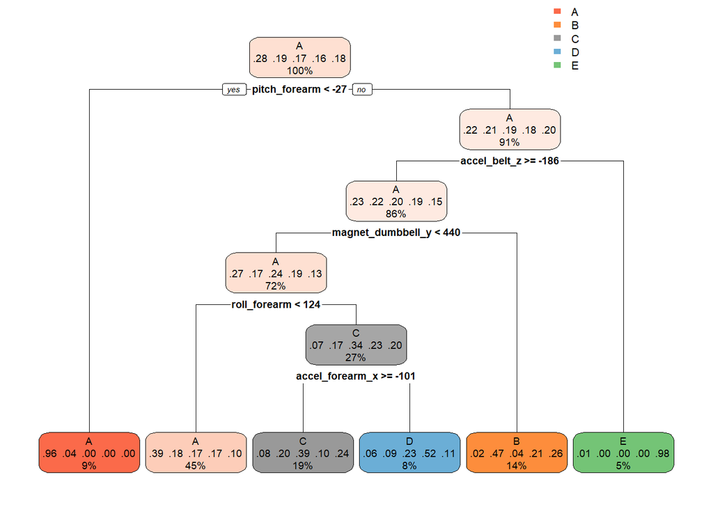

```r
rpart.plot(DT_modfit$finalModel, roundint=FALSE)
```

## ** 5. Random Forest Model **

```r
RF_modfit <- train(classe ~ ., data = training, method = "rf", ntree = 100)
```

Prediction in terms of Random Forest Model

```r
RF_prediction <- predict(RF_modfit, testing)
RF_pred_conf <- confusionMatrix(RF_prediction, testing$classe)
RF_pred_conf
```

```
## Confusion Matrix and Statistics
##
##           Reference
## Prediction    A    B    C    D    E
##          A 2230   14    0    0    0
##          B    1 1495   10    0    0
##          C    1    7 1353   17    1
##          D    0    0    5 1268    5
##          E    0    2    0    1 1436
##
## Overall Statistics
##
##                Accuracy : 0.9918
##                  95% CI : (0.9896, 0.9937)
##     No Information Rate : 0.2845
##     P-Value [Acc > NIR] : < 2.2e-16
##
##                   Kappa : 0.9897
##  Mcnemar's Test P-Value : NA
##
## Statistics by Class:
##
##                      Class: A Class: B Class: C Class: D Class: E
## Sensitivity            0.9991   0.9848   0.9890   0.9860   0.9958
## Specificity            0.9975   0.9983   0.9960   0.9985   0.9995
## Pos Pred Value         0.9938   0.9927   0.9811   0.9922   0.9979
## Neg Pred Value         0.9996   0.9964   0.9977   0.9973   0.9991
## Prevalence             0.2845   0.1935   0.1744   0.1639   0.1838
## Detection Rate         0.2842   0.1905   0.1724   0.1616   0.1830
## Detection Prevalence   0.2860   0.1919   0.1758   0.1629   0.1834
## Balanced Accuracy      0.9983   0.9916   0.9925   0.9922   0.9977
```

Here is the plot

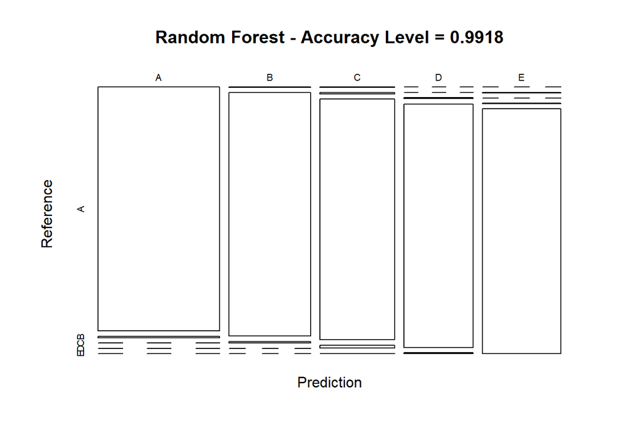

```r
plot(RF_pred_conf$table, col = RF_pred_conf$byClass,
     main = paste("Random Forest - Accuracy Level =",
                  round(RF_pred_conf$overall['Accuracy'], 4)))
```

From the Confusion Matrix, we can clearly see that the prediction accuracy of Random Forest model is 99% which is satisfactory.

## ** 6. Gradient Boosting Model **

```r
GBM_modfit <- train(classe ~ ., data = training, method = "gbm", verbose = FALSE)
GBM_modfit$finalModel
```

```
## A gradient boosted model with multinomial loss function.
## 150 iterations were performed.
## There were 51 predictors of which 42 had non-zero influence.
```

Prediction in terms of GBM Model

```r
#GBM_prediction <- predict(GBM_modfit, testing, type = "class", n.trees = 5, type = link)
GBM_prediction <- predict(GBM_modfit, testing)

GBM_pred_conf <- confusionMatrix(GBM_prediction, testing$classe)
GBM_pred_conf
```

```
## Confusion Matrix and Statistics
##
##           Reference
## Prediction    A    B    C    D    E
##          A 2191   61    0    2    1
##          B   26 1414   40    7   11
##          C    8   36 1313   40   16
##          D    6    1   12 1220   18
##          E    1    6    3   17 1396
##
## Overall Statistics
##
##                Accuracy : 0.9602
##                  95% CI : (0.9557, 0.9645)
##     No Information Rate : 0.2845
##     P-Value [Acc > NIR] : < 2.2e-16
##
##                   Kappa : 0.9497
##  Mcnemar's Test P-Value : 4.337e-08
##
## Statistics by Class:
##
##                      Class: A Class: B Class: C Class: D Class: E
## Sensitivity            0.9816   0.9315   0.9598   0.9487   0.9681
## Specificity            0.9886   0.9867   0.9846   0.9944   0.9958
## Pos Pred Value         0.9716   0.9439   0.9292   0.9706   0.9810
## Neg Pred Value         0.9927   0.9836   0.9915   0.9900   0.9928
## Prevalence             0.2845   0.1935   0.1744   0.1639   0.1838
## Detection Rate         0.2793   0.1802   0.1673   0.1555   0.1779
## Detection Prevalence   0.2874   0.1909   0.1801   0.1602   0.1814
## Balanced Accuracy      0.9851   0.9591   0.9722   0.9715   0.9819
```

Here is the plot

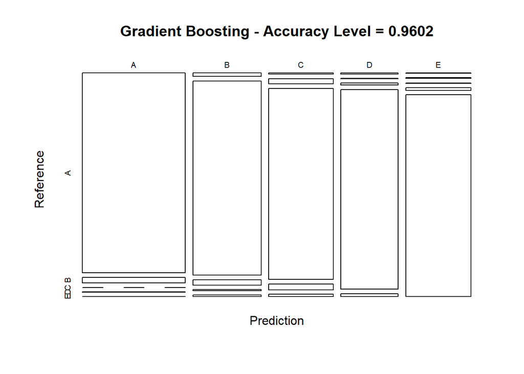

```r
plot(GBM_pred_conf$table, col = GBM_pred_conf$byClass,
     main = paste("Gradient Boosting - Accuracy Level =",
                  round(GBM_pred_conf$overall['Accuracy'], 4)))
```

#### ** Now we need to see how each model has predicted the validation dataset across the classifications. ** We are not considering Decision Tree model as it didn’t reach the satisfactory prediction accuracy level. SO only Random Forest and Gradient Boosting methods are being compared.

```r
RF_pred_conf$overall
```

```
##       Accuracy          Kappa  AccuracyLower  AccuracyUpper   AccuracyNull
##      0.9918430      0.9896806      0.9895954      0.9937126      0.2844762
## AccuracyPValue  McnemarPValue
##      0.0000000            NaN
```

```r
GBM_pred_conf$overall
```

```
##       Accuracy          Kappa  AccuracyLower  AccuracyUpper   AccuracyNull
##   9.602345e-01   9.496836e-01   9.556727e-01   9.644503e-01   2.844762e-01
## AccuracyPValue  McnemarPValue
##   0.000000e+00   4.336741e-08
```

# ** Conclusion **

After checking the **Overall Statistics data**, the Random Forest model has definitely more accuracy than GBM. Hence we will be selecting **Random Forest model** for final prediction from **org_testing_data** .

## ** Final Prediction- Applying selected model on the Test Data **

```r
Final_RF_prediction <- predict(RF_modfit, org_testing_data )
Final_RF_prediction
```

```
##  [1] B A B A A E D B A A B C B A E E A B B B
## Levels: A B C D E
```